# HW1 keys

Dr. Xiang Ji @ Tulane

22 September, 2020

```r
rm(list = ls()) # clean-up workspace
```

## Q1.

Why not test equality with floating point numbers

```r
seven <- .7
two <- .2
one <- .1
```

### a

Let’s look at the internal representation:

```r
sprintf("%a", c(seven, two, one)) # three numbers (Hexadecimal)
```

```
## [1] "0x1.6666666666666p-1" "0x1.999999999999ap-3" "0x1.999999999999ap-4"
```

### b

```r
1 == (seven + two) + one
```

```
## [1] FALSE
```

### c

```r
1 == seven + (two + one)
```

```
## [1] TRUE
```

### d

```r
1 == (seven + one) + two
```

```
## [1] TRUE
```

### e

```r
sprintf("%a", c(seven + two, one))
```

```
## [1] "0x1.cccccccccccccp-1" "0x1.999999999999ap-4"
```

```r
sprintf("%a", (seven + two) + one)
```

```
## [1] "0x1.fffffffffffffp-1"
```

For the partial sum $0.7+0.2$, computer

1. aligns the exponent
2. performs addition, and then
3. normalizes the result.

So we get

$$\begin{aligned}
&1.0110 \dots 0110 \times 2^{-1}\\
+&0.0110 \dots 0110 \times 2^{-1}\\
=&1.1100 \dots 1100 \times 2^{-1}\\
\end{aligned}$$

Not in the aligning exponent step, we lost the last two digits of 0.2.

Next we add the partial sum to 0.1

$$\begin{aligned}
&1.1100 \dots 1100 \times 2^{-1}\\
+&0.0011 \dots 0011 \times 2^{-1}\\
=&1.1111 \dots 1111 \times 2^{-1}\\
\end{aligned}$$

Note again, we lost three digits from 0.1 when aligning exponents. The final result is a bit off from 1.

```r
sprintf("%a", 1)
```

```
## [1] "0x1p+0"
```

You may work on the other two orders: $0.7 + (0.2 + 0.1)$ and $(0.7 + 0.1) + 0.2$, which lead to exact 1.

```r
# 0.7 + (0.2 + 0.1)
sprintf("%a", c(seven, two + one)) # partial sum
```

```
## [1] "0x1.6666666666666p-1" "0x1.3333333333334p-2"
```

```r
sprintf("%a", seven + (two + one))
```

```
## [1] "0x1p+0"
```

```r
# (0.7 + 0.1) + 0.2
sprintf("%a", c(seven + one, two)) # partial sum
```

```
## [1] "0x1.9999999999999p-1" "0x1.999999999999ap-3"
```

```r
sprintf("%a", (seven + one) + two)
```

```
## [1] "0x1p+0"
```

## Q2

This is simply the polynomial $y = (x - 1) ^ 7$ expanded. $y$ values are very close to 0 when $x$ are close to 1. This calculation is taking differences of very close numbers and losing precision (catastrophic cancellation 2). The results don’t appear like polynomials due to round-off errors.

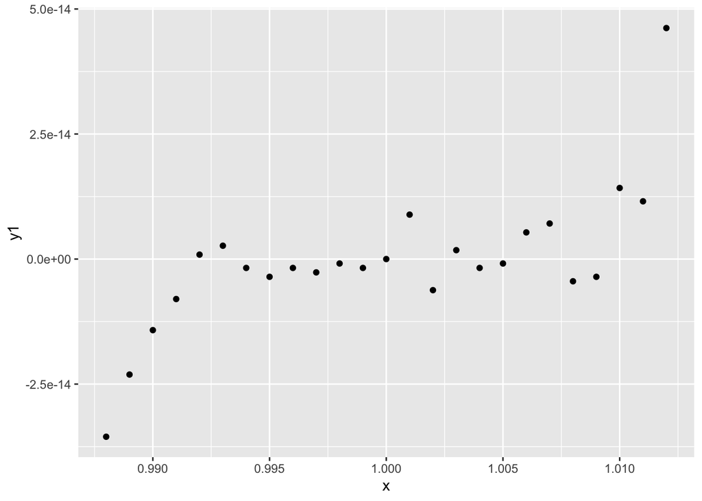

```r
library(ggplot2)
library("tidyverse")
x <- seq(from = 0.988, to = 1.012, by = 0.001)
y1 <- x^7 - 7 * x^6 + 21 * x^5 - 35 * x^4 + 35 * x^3 - 21 * x^2 + 7 * x - 1
q3.df <- tibble(x = x, y1 = y1)
ggplot(data = q3.df) +
  geom_point(mapping = aes(x = x, y = y1))
```

This avoids catastrophic cancellation and the result looks nicer.

```r
y2 <- (x - 1)^7
add_column(q3.df, y2 = y2)
```

```
## # A tibble: 25 x 3
##        x        y1        y2
##    <dbl>     <dbl>     <dbl>
##  1 0.988 -3.55e-14 -3.58e-14
##  2 0.989 -2.31e-14 -1.95e-14
##  3 0.99  -1.42e-14 -1.00e-14
##  4 0.991 -7.99e-15 -4.78e-15
##  5 0.992  8.88e-16 -2.10e-15
##  6 0.993  2.66e-15 -8.24e-16
##  7 0.994 -1.78e-15 -2.80e-16
##  8 0.995 -3.55e-15 -7.81e-17
##  9 0.996 -1.78e-15 -1.64e-17
## 10 0.997 -2.66e-15 -2.19e-18
## # … with 15 more rows
```

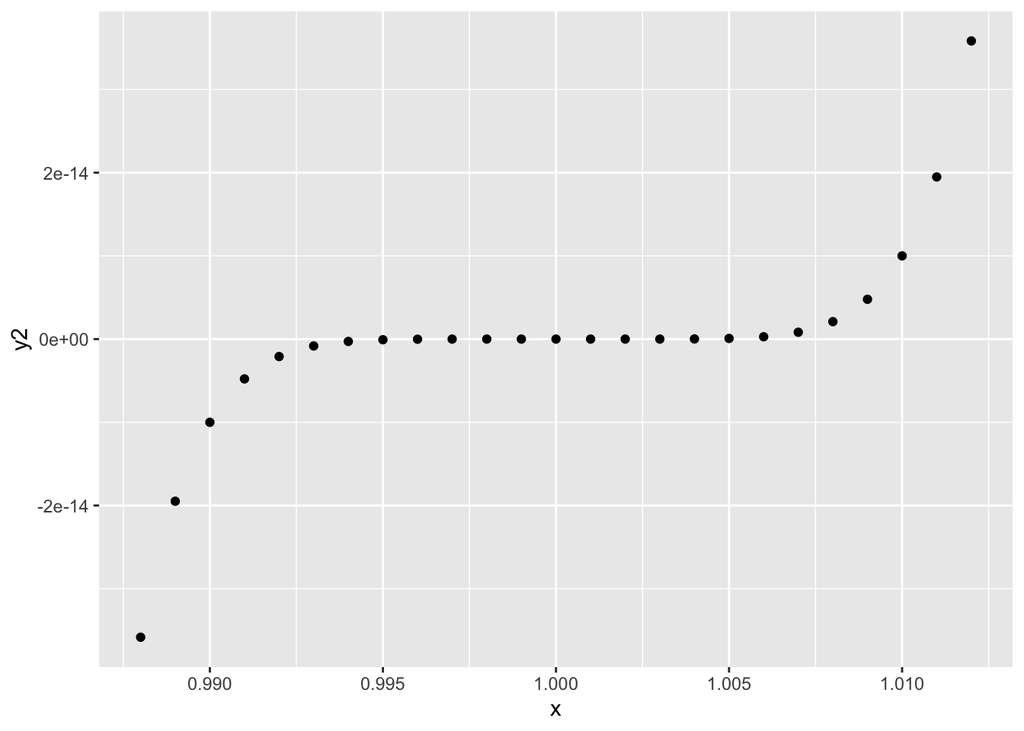

```r
ggplot(data = q3.df) +
  geom_point(mapping = aes(x = x, y = y2))
```

## Q3

### a

```r
u <- c(1, 2, 3, 3, 2, 1)
d <- as.numeric(t(u) %*% u)
d
```

```
## [1] 28
```

```r
# another way
d <- as.numeric(crossprod(u))
d
```

```
## [1] 28
```

```r
# Compute U = I - (2/d) u u' where d = u'u.
U <- diag(6) - (2 / d) * u %*% t(u)
U
```

```
##             [,1]       [,2]       [,3]       [,4]       [,5]        [,6]
## [1,]  0.92857143 -0.1428571 -0.2142857 -0.2142857 -0.1428571 -0.07142857
## [2,] -0.14285714  0.7142857 -0.4285714 -0.4285714 -0.2857143 -0.14285714
## [3,] -0.21428571 -0.4285714  0.3571429 -0.6428571 -0.4285714 -0.21428571
## [4,] -0.21428571 -0.4285714 -0.6428571  0.3571429 -0.4285714 -0.21428571
## [5,] -0.14285714 -0.2857143 -0.4285714 -0.4285714  0.7142857 -0.14285714
## [6,] -0.07142857 -0.1428571 -0.2142857 -0.2142857 -0.1428571  0.92857143
```

```r
# another way (may be faster) to compute outer product
U <- diag(6) - (2 / d) * tcrossprod(u)
U
```

```
##             [,1]       [,2]       [,3]       [,4]       [,5]        [,6]
## [1,]  0.92857143 -0.1428571 -0.2142857 -0.2142857 -0.1428571 -0.07142857
## [2,] -0.14285714  0.7142857 -0.4285714 -0.4285714 -0.2857143 -0.14285714
## [3,] -0.21428571 -0.4285714  0.3571429 -0.6428571 -0.4285714 -0.21428571
## [4,] -0.21428571 -0.4285714 -0.6428571  0.3571429 -0.4285714 -0.21428571
## [5,] -0.14285714 -0.2857143 -0.4285714 -0.4285714  0.7142857 -0.14285714
## [6,] -0.07142857 -0.1428571 -0.2142857 -0.2142857 -0.1428571  0.92857143
```

```r
# yet another way to compute outer product
U <- diag(6) - (2 / d) * outer(u, u)
U
```

```
##             [,1]       [,2]       [,3]       [,4]       [,5]        [,6]
## [1,]  0.92857143 -0.1428571 -0.2142857 -0.2142857 -0.1428571 -0.07142857
## [2,] -0.14285714  0.7142857 -0.4285714 -0.4285714 -0.2857143 -0.14285714
## [3,] -0.21428571 -0.4285714  0.3571429 -0.6428571 -0.4285714 -0.21428571
## [4,] -0.21428571 -0.4285714 -0.6428571  0.3571429 -0.4285714 -0.21428571
## [5,] -0.14285714 -0.2857143 -0.4285714 -0.4285714  0.7142857 -0.14285714
## [6,] -0.07142857 -0.1428571 -0.2142857 -0.2142857 -0.1428571  0.92857143
```

### b

```r
# Let M = U*U
M <- U %*% U
# Find the largest off-diagonal elements of U*U.
max(M[col(M) != row(M)])
```

```
## [1] -2.775558e-17
```

```r
# Find the smallest off-diagonal elements of U*U.
min(M[col(M) != row(M)])
```

```
## [1] -1.491862e-16
```

### c

```r
# two ways to find the largest diagonal elements of U*U
max(diag(M))
```

```
## [1] 1
```

```r
max(M[col(M) == row(M)])
```

```
## [1] 1
```

```r
# two ways to find the smallest diagonal elements of U*U
min(diag(M))
```

```
## [1] 1
```

```r
min(M[col(M) == row(M)])
```

```
## [1] 1
```

### d

```r
# Compute U*u
U %*% u
```

```
##      [,1]
## [1,]   -1
## [2,]   -2
## [3,]   -3
## [4,]   -3
## [5,]   -2
## [6,]   -1
```

### e

```r
# Compute max_i sum_j abs(U(i,j))
max(rowSums(abs(U)))
```

```
## [1] 2.285714
```

### f

```r
# Print the third row of U
U[3, ]
```

```
## [1] -0.2142857 -0.4285714  0.3571429 -0.6428571 -0.4285714 -0.2142857
```

### g

```r
# Print the elements of the second column below the diagonal
U[3:dim(U)[1], 2]
```

```
## [1] -0.4285714 -0.4285714 -0.2857143 -0.1428571
```

### h

```r
# Let A be the first three columns of U
A <- U[, 1:3]
# Compute P = AA'
P <- A %*% t(A)
P
```

```
##               [,1]          [,2]          [,3]          [,4]          [,5]
## [1,]  9.285714e-01 -1.428571e-01 -2.142857e-01 -2.775558e-17 -2.775558e-17
## [2,] -1.428571e-01  7.142857e-01 -4.285714e-01 -5.551115e-17 -2.775558e-17
## [3,] -2.142857e-01 -4.285714e-01  3.571429e-01 -2.775558e-17 -5.551115e-17
## [4,] -2.775558e-17 -5.551115e-17 -2.775558e-17  6.428571e-01  4.285714e-01
## [5,] -2.775558e-17 -2.775558e-17 -5.551115e-17  4.285714e-01  2.857143e-01
## [6,] -1.387779e-17 -1.387779e-17 -2.775558e-17  2.142857e-01  1.428571e-01
##               [,6]
## [1,] -1.387779e-17
## [2,] -1.387779e-17
## [3,] -2.775558e-17
## [4,]  2.142857e-01
## [5,]  1.428571e-01
## [6,]  7.142857e-02
```

```r
# another (preferred) way to compute outer product
P <- tcrossprod(A)
P
```

```
##               [,1]          [,2]          [,3]          [,4]          [,5]
## [1,]  9.285714e-01 -1.428571e-01 -2.142857e-01 -2.775558e-17 -2.775558e-17
## [2,] -1.428571e-01  7.142857e-01 -4.285714e-01 -5.551115e-17 -2.775558e-17
## [3,] -2.142857e-01 -4.285714e-01  3.571429e-01 -2.775558e-17 -5.551115e-17
## [4,] -2.775558e-17 -5.551115e-17 -2.775558e-17  6.428571e-01  4.285714e-01
## [5,] -2.775558e-17 -2.775558e-17 -5.551115e-17  4.285714e-01  2.857143e-01
## [6,] -1.387779e-17 -1.387779e-17 -2.775558e-17  2.142857e-01  1.428571e-01
##               [,6]
## [1,] -1.387779e-17
## [2,] -1.387779e-17
## [3,] -2.775558e-17
## [4,]  2.142857e-01
## [5,]  1.428571e-01
## [6,]  7.142857e-02
```

### i

```r
# Compute P*P-P
P%*%P-P
```

```
##               [,1]          [,2]         [,3]          [,4]          [,5]
## [1,]  0.000000e+00  0.000000e+00 0.000000e+00 -1.685160e-17 -3.965082e-18
## [2,]  0.000000e+00  1.110223e-16 0.000000e+00 -1.883414e-17  1.982541e-18
## [3,]  0.000000e+00  0.000000e+00 0.000000e+00  1.232595e-32  2.180795e-17
## [4,] -1.685160e-17 -1.883414e-17 1.232595e-32 -1.110223e-16 -5.551115e-17
## [5,] -3.965082e-18  1.982541e-18 2.180795e-17 -5.551115e-17 -5.551115e-17
## [6,] -1.982541e-18  9.912706e-19 1.090398e-17 -2.775558e-17 -2.775558e-17
##               [,6]
## [1,] -1.982541e-18
## [2,]  9.912706e-19
## [3,]  1.090398e-17
## [4,] -2.775558e-17
## [5,] -2.775558e-17
## [6,] -1.387779e-17
```

### j

```r
# Let B be the last three columns of U
B <- U[, 4:6]
# Compute Q = BB'
Q <- B %*% t(B)
Q
```

```
##               [,1]          [,2]          [,3]          [,4]          [,5]
## [1,]  7.142857e-02  1.428571e-01  2.142857e-01 -2.602085e-17 -1.214306e-17
## [2,]  1.428571e-01  2.857143e-01  4.285714e-01 -5.204170e-17 -2.428613e-17
## [3,]  2.142857e-01  4.285714e-01  6.428571e-01 -2.775558e-17 -3.816392e-17
## [4,] -2.602085e-17 -5.204170e-17 -2.775558e-17  3.571429e-01 -4.285714e-01
## [5,] -1.214306e-17 -2.428613e-17 -3.816392e-17 -4.285714e-01  7.142857e-01
## [6,] -1.387779e-17 -2.775558e-17 -2.775558e-17 -2.142857e-01 -1.428571e-01
##               [,6]
## [1,] -1.387779e-17
## [2,] -2.775558e-17
## [3,] -2.775558e-17
## [4,] -2.142857e-01
## [5,] -1.428571e-01
## [6,]  9.285714e-01
```

```r
# another way to compute outer product
Q <- tcrossprod(B)
Q
```

```
##               [,1]          [,2]          [,3]          [,4]          [,5]
## [1,]  7.142857e-02  1.428571e-01  2.142857e-01 -2.602085e-17 -1.214306e-17
## [2,]  1.428571e-01  2.857143e-01  4.285714e-01 -5.204170e-17 -2.428613e-17
## [3,]  2.142857e-01  4.285714e-01  6.428571e-01 -2.775558e-17 -3.816392e-17
## [4,] -2.602085e-17 -5.204170e-17 -2.775558e-17  3.571429e-01 -4.285714e-01
## [5,] -1.214306e-17 -2.428613e-17 -3.816392e-17 -4.285714e-01  7.142857e-01
## [6,] -1.387779e-17 -2.775558e-17 -2.775558e-17 -2.142857e-01 -1.428571e-01
##               [,6]
## [1,] -1.387779e-17
## [2,] -2.775558e-17
## [3,] -2.775558e-17
## [4,] -2.142857e-01
## [5,] -1.428571e-01
## [6,]  9.285714e-01
```

### k

```r
# Compute Q*Q-Q
Q%*%Q-Q
```

```
##               [,1]          [,2]          [,3]          [,4]          [,5]
## [1,] -1.387779e-17 -2.775558e-17 -2.775558e-17  9.664888e-18  4.088991e-18
## [2,] -2.775558e-17 -5.551115e-17 -5.551115e-17  1.932978e-17  8.177982e-18
## [3,] -2.775558e-17 -5.551115e-17 -1.110223e-16 -5.575897e-18 -1.078007e-17
## [4,]  9.664888e-18  1.932978e-17 -5.575897e-18  5.551115e-17 -5.551115e-17
## [5,]  4.088991e-18  8.177982e-18 -1.078007e-17 -5.551115e-17  1.110223e-16
## [6,] -2.602085e-18 -5.204170e-18 -1.932978e-17  0.000000e+00 -2.775558e-17
##               [,6]
## [1,] -2.602085e-18
## [2,] -5.204170e-18
## [3,] -1.932978e-17
## [4,]  0.000000e+00
## [5,] -2.775558e-17
## [6,]  0.000000e+00
```

### l

```r
# Compute P+Q
P+Q
```

```
##               [,1]          [,2]          [,3]          [,4]          [,5]
## [1,]  1.000000e+00 -2.775558e-17 -5.551115e-17 -5.377643e-17 -3.989864e-17
## [2,] -2.775558e-17  1.000000e+00 -1.110223e-16 -1.075529e-16 -5.204170e-17
## [3,] -5.551115e-17 -1.110223e-16  1.000000e+00 -5.551115e-17 -9.367507e-17
## [4,] -5.377643e-17 -1.075529e-16 -5.551115e-17  1.000000e+00 -1.665335e-16
## [5,] -3.989864e-17 -5.204170e-17 -9.367507e-17 -1.665335e-16  1.000000e+00
## [6,] -2.775558e-17 -4.163336e-17 -5.551115e-17 -5.551115e-17 -2.775558e-17
##               [,6]
## [1,] -2.775558e-17
## [2,] -4.163336e-17
## [3,] -5.551115e-17
## [4,] -5.551115e-17
## [5,] -2.775558e-17
## [6,]  1.000000e+00
```

## Q4

```r
# Read in the matrix in the file 'oringp.dat'.
# The columns are flight number, date, number of O-rings, number failed,
# and temperature at launch.
inputFile <- "http://tulane-math7360.github.io/HW/HW1/oringp.dat"
inputData <- read.table(file = inputFile,
                        col.names = c("flightNumber", "date", "numberOrings", "numberFailed", "tempAtLaunch"))
str(inputData)
```

```
## 'data.frame':    24 obs. of  5 variables:
##  $ flightNumber: chr  "1" "2" "3" "5" ...
##  $ date        : chr  "4/12/81" "11/12/81" "3/22/82" "11/11/82" ...
##  $ numberOrings: int  6 6 6 6 6 6 6 6 6 6 ...
##  $ numberFailed: int  0 1 0 0 0 0 0 0 1 1 ...
##  $ tempAtLaunch: int  66 70 69 68 67 72 73 70 57 63 ...
```

```r
inputData <- read_table(file = inputFile,
                        col_names = c("flightNumber", "date", "numberOrings", "numberFailed", "tempAtLaunch"))
# Compute the correlation between number of failures and temperature at launch,
# deleting the last, missing observation (the disaster).
cor(inputData$numberFailed[-24], inputData$tempAtLaunch[-24])
```

```
## [1] -0.5613284
```

## Q5 from [Advanced R](http://adv-r.had.co.nz/Functions.html)

Quiz questions 1, 2, 4, 5

## Q6

### a

```r
create.matrix.A <- function(n) {
  # create a matrix with all 0
  B <- matrix(0, n, n)
  # Let the n*n matrix A have elements A(i,j)=1/(|i-j|+1)
  A <- 1 / (abs(row(B) - col(B)) + 1)
  return(A)
}
```

### b

```r
A <- create.matrix.A(10)
A
```

```
##            [,1]      [,2]      [,3]      [,4]      [,5]      [,6]      [,7]
##  [1,] 1.0000000 0.5000000 0.3333333 0.2500000 0.2000000 0.1666667 0.1428571
##  [2,] 0.5000000 1.0000000 0.5000000 0.3333333 0.2500000 0.2000000 0.1666667
##  [3,] 0.3333333 0.5000000 1.0000000 0.5000000 0.3333333 0.2500000 0.2000000
##  [4,] 0.2500000 0.3333333 0.5000000 1.0000000 0.5000000 0.3333333 0.2500000
##  [5,] 0.2000000 0.2500000 0.3333333 0.5000000 1.0000000 0.5000000 0.3333333
##  [6,] 0.1666667 0.2000000 0.2500000 0.3333333 0.5000000 1.0000000 0.5000000
##  [7,] 0.1428571 0.1666667 0.2000000 0.2500000 0.3333333 0.5000000 1.0000000
##  [8,] 0.1250000 0.1428571 0.1666667 0.2000000 0.2500000 0.3333333 0.5000000
##  [9,] 0.1111111 0.1250000 0.1428571 0.1666667 0.2000000 0.2500000 0.3333333
## [10,] 0.1000000 0.1111111 0.1250000 0.1428571 0.1666667 0.2000000 0.2500000
##            [,8]      [,9]     [,10]
##  [1,] 0.1250000 0.1111111 0.1000000
##  [2,] 0.1428571 0.1250000 0.1111111
##  [3,] 0.1666667 0.1428571 0.1250000
##  [4,] 0.2000000 0.1666667 0.1428571
##  [5,] 0.2500000 0.2000000 0.1666667
##  [6,] 0.3333333 0.2500000 0.2000000
##  [7,] 0.5000000 0.3333333 0.2500000
##  [8,] 1.0000000 0.5000000 0.3333333
##  [9,] 0.5000000 1.0000000 0.5000000
## [10,] 0.3333333 0.5000000 1.0000000
```

### c

```r
R <- chol(A)
R
```

```
##       [,1]      [,2]      [,3]      [,4]      [,5]      [,6]      [,7]
##  [1,]    1 0.5000000 0.3333333 0.2500000 0.2000000 0.1666667 0.1428571
##  [2,]    0 0.8660254 0.3849002 0.2405626 0.1732051 0.1347151 0.1099715
##  [3,]    0 0.0000000 0.8606630 0.3765400 0.2323790 0.1656776 0.1278699
##  [4,]    0 0.0000000 0.0000000 0.8589803 0.3735049 0.2291962 0.1626144
##  [5,]    0 0.0000000 0.0000000 0.0000000 0.8581924 0.3719766 0.2275279
##  [6,]    0 0.0000000 0.0000000 0.0000000 0.0000000 0.8577456 0.3710713
##  [7,]    0 0.0000000 0.0000000 0.0000000 0.0000000 0.0000000 0.8574620
##  [8,]    0 0.0000000 0.0000000 0.0000000 0.0000000 0.0000000 0.0000000
##  [9,]    0 0.0000000 0.0000000 0.0000000 0.0000000 0.0000000 0.0000000
## [10,]    0 0.0000000 0.0000000 0.0000000 0.0000000 0.0000000 0.0000000
##             [,8]       [,9]      [,10]
##  [1,] 0.12500000 0.11111111 0.10000000
##  [2,] 0.09278844 0.08018754 0.07056503
##  [3,] 0.10374063 0.08709090 0.07494940
##  [4,] 0.12499247 0.10105651 0.08458911
##  [5,] 0.16096174 0.12340555 0.09955033
##  [6,] 0.22651321 0.15993584 0.12240439
##  [7,] 0.37047945 0.22583697 0.15924172
##  [8,] 0.85726783 0.37006563 0.22535737
##  [9,] 0.00000000 0.85712760 0.36976194
## [10,] 0.00000000 0.00000000 0.85702216
```

### d

```r
# two ways to find determinant of A; first way is much more efficient
system.time(prod(diag(R))^2)
```

```
##    user  system elapsed
##       0       0       0
```

```r
system.time(det(A))
```

```
##    user  system elapsed
##   0.000   0.000   0.001
```